# Tutorial

```r
#load Lund Taxonomy Classifier
library(LundTax2023Classifier)
library(knitr)
library(grid)
```

# Lund Taxonomy Classifier

This package depends on a set of internal and exported functions. The main funcitons inteded for the user are; `lundtax_predict_sub`, `lundtax_calc_sigscore`, `plot_hm_signatures`, `plot_hm_sigscores`, `plot_ranked_score`. In this tutorial, we will demonstrate how to use these functions, using the bundled data to get the most out from this package.

## Bundled Data

Before we get started, let’s start with exploring some of the relevant bunlded data objects.

### Expression Data

This package includes an example expression data set. This data is a subset of samples from the Sjodahl 2017 paper. Let’s first see the dimensions of the data object.

```r
dim(sjodahl_2017)
```

```
## [1] 15697   267
```

```r
knitr::kable(sjodahl_2017[1:5, 1:5],
             caption = "Table 1. Bundled expression data subset")
```

Table 1. Bundled expression data subset

|  | 1.CEL | 2.CEL | 3.CEL | 4.CEL | 5.CEL |
| --- | --- | --- | --- | --- | --- |
| A1CF | 4.248274 | 4.153923 | 4.186689 | 4.877813 | 4.106269 |
| A2M | 8.348800 | 7.969504 | 10.755738 | 8.467495 | 8.979223 |
| A2ML1 | 6.694896 | 4.442973 | 8.871067 | 4.392010 | 7.685045 |
| A4GALT | 7.255671 | 6.337239 | 6.925670 | 6.239185 | 6.032115 |
| A4GNT | 3.740418 | 3.830598 | 3.999331 | 3.813662 | 3.718752 |

### Metadata

The package also includes meta data for the expression data. The metadata can be used to aggregate the prediction calls, allowing for interesting association between various metadata variables and specific subtype. Let’s explore this data set by overviewing what clinical information is available.

```r
str(sjodahl_2017_meta)
```

```
## 'data.frame':    267 obs. of  25 variables:
##  $ sample_id        : chr  "1.CEL" "2.CEL" "3.CEL" "4.CEL" ...
##  $ cluster_order    : int  13 162 154 11 251 55 254 278 155 101 ...
##  $ age              : num  74.7 53.6 65.5 70.8 64.2 67.2 77.3 66.2 59.6 64.1 ...
##  $ gender           : Factor w/ 2 levels "Female","Male": 2 2 2 2 1 2 2 2 1 2 ...
##  $ region_cx        : Factor w/ 4 levels "HBG","LUND","MALMO",..: 3 3 3 3 3 3 3 3 1 3 ...
##  $ turb_grade       : Factor w/ 3 levels "0","1","N/A": 2 3 3 2 2 2 2 3 2 2 ...
##  $ turb_stage       : Factor w/ 3 levels "0","1","N/A": 2 2 2 2 2 2 2 1 2 2 ...
##  $ turb_skiv        : Factor w/ 3 levels "0","1","N/A": 1 1 1 2 2 1 2 1 2 1 ...
##  $ turb_cis         : Factor w/ 3 levels "0","1","N/A": 1 1 1 1 1 1 1 1 1 2 ...
##  $ turb_lvi         : Factor w/ 3 levels "0","1","N/A": 2 1 1 2 2 2 2 2 1 1 ...
##  $ turb_necros      : Factor w/ 4 levels "0","1","2","N/A": 1 1 2 2 3 3 3 3 2 2 ...
##  $ turb_apoptos     : Factor w/ 3 levels "0","1","N/A": 2 1 1 2 2 2 2 2 2 2 ...
##  $ variant_histology: Factor w/ 2 levels "0","1": 1 2 2 1 1 1 1 2 1 1 ...
##  $ cT               : Factor w/ 5 levels "1","2","3","4",..: 3 2 1 2 2 3 2 2 3 2 ...
##  $ cN               : Factor w/ 3 levels "0","1","N/A": 1 1 1 1 1 1 1 1 1 1 ...
##  $ hydroneph        : Factor w/ 2 levels "0","1": 2 1 1 1 1 1 2 1 1 2 ...
##  $ pTCx             : Factor w/ 10 levels "0","1","2","3",..: 6 8 5 8 4 5 1 2 8 9 ...
##  $ pN               : Factor w/ 5 levels "0","1","2","3",..: 3 1 1 1 1 1 3 1 1 3 ...
##  $ adj_chemo        : Factor w/ 2 levels "0","1": 2 1 1 1 1 1 1 1 1 2 ...
##  $ surv_os_event    : Factor w/ 2 levels "0","1": 2 2 1 2 1 2 2 2 2 2 ...
##  $ surv_os_time     : num  12.8 13.5 100.4 3 77.6 ...
##  $ surv_css_event   : Factor w/ 2 levels "0","1": 2 2 1 1 1 2 2 1 1 2 ...
##  $ surv_css_time    : num  12.8 13.5 100.4 3 77.6 ...
##  $ surv_pfs_event   : Factor w/ 2 levels "0","1": 2 2 1 1 1 2 2 1 1 2 ...
##  $ surv_pfs_time    : num  11.6 10.6 100.4 3 77.6 ...
```

If the user wants to use their own metadata, this should be in a data frame format wiith unique sample identifiers in a column called `sample_id`. For a more detailed explanation of the variables, see that data set documentation.

### Other Bundled Objects

this package also includes a variety of data objects needed for the predictor. For example, classifiers for predicting grade and subtype, lists with genes identifiers for making prediction calls and gene signatures. Let’s explore a few of these.

The `gene_list` holds information on gene identifiers that the predictor is based on. This object has gene identfiers in both HGNC and Ensembl format, allowing the incoming data to be in either of these formats.

```r
knitr::kable(head(gene_list, 5),
             caption = "Table 2. Gene List")
```

Table 2. Gene List

| ensembl_gene_id | hgnc_symbol |
| --- | --- |
| ENSG00000109576 | AADAT |
| ENSG00000183044 | ABAT |
| ENSG00000108846 | ABCC3 |
| ENSG00000114770 | ABCC5 |
| ENSG00000106077 | ABHD11 |

How many genes in total, are included in the `gene_list` object?

```r
nrow(gene_list)
```

```
## [1] 1900
```

The `signatures` object has all the information on what genes are associated with what signature. This object is a list of 6 data frames, for different signatures. Typically, the columns of each data frame are the following; `hgnc_symbol`, `ensembl_gene_id` and `signature`. Let’s have a look at the immune signatures object in this list.

```r
knitr::kable(table(signatures$immune$signature),
             caption = "Table 3. Immune Signatures",
             col.names = c("Signature", "Genes (n)"))
```

Table 3. Immune Signatures

| Signature | Genes (n) |
| --- | --- |
| B-cells | 8 |
| Cytotoxicity Score | 10 |
| Endothelial cells | 12 |
| Fibroblasts | 4 |
| M2 macrophage | 3 |
| Macrophages | 4 |
| Monocytic lineage | 3 |
| Myeloid Dendritic Cells | 5 |
| Neutrophils | 5 |
| NK-cells | 6 |
| Smooth muscle | 4 |
| T-cells | 6 |
| T-cells CD8+ | 1 |

## Subtype Prediction

The main function in this package is `lundtax_predict_sub`. This function makes prediction calls based on gene expression data. It also internally calls `lundtax_calc_sigscore` to calculate signature scores for a variety of,for the subtype, relevant signature scores. The main input for this function is a data object with expression values, given to the `this_data` parameter. This should be a data frame or matrix with expression values, gene identifiers in as row names and samples in columns. The function supports gene identifiers in one of the following formats; **HGNC symbols** (default) or **Ensembl Gene IDs**. The format for the provided gene identifiers should be given to the `gene_id` parameter. This function also depends on the `predict_RF` function from `multiclassPairs`. Thus, the function can also take arguments from this function. For example, if required genes are missing from the input data, the user can run the prediction function with `impute = TRUE`.

### Example 1 - Predict Subtype

In this first example we will call this function on the bundled expression data to determine a subtype for each of the included samples. Note, that we run this example with `impute = TRUE` to compensate for missing genes in the demo data set. For transparency, all other parameters are called with default parameters for demonstrating purposes.

```r
sjodahl_predicted = lundtax_predict_sub(this_data = sjodahl_2017,
                                        gene_id = "hgnc_symbol",
                                        impute = TRUE,
                                        threshold_progression = 0.58,
                                        log_transform = TRUE,
                                        adjust = FALSE,
                                        adj_factor = 5.1431,
                                        impute_reject = 0.67,
                                        impute_kNN = 5,
                                        subtype_only = FALSE,
                                        include_data = FALSE,
                                        include_pred_scores = TRUE,
                                        verbose = FALSE)
```

Let’s explore what the returned object looks like. The return is a lsit of 4, with the following information in it:

```r
knitr::kable(summary(sjodahl_predicted),
             caption = "Table 4. Prediction Calls",
             col.names = c("Object", "Length", "Class", "Mode"))
```

Table 4. Prediction Calls

| Object | Length | Class | Mode |
| --- | --- | --- | --- |
| subtype_scores | 2136 | -none- | numeric |
| predictions_7classes | 267 | -none- | character |
| predictions_5classes | 267 | -none- | character |
| scores | 35 | data.frame | list |

The `subtype_scores` object holds all the subtype prediction scores for all included samples.

```r
knitr::kable(head(sjodahl_predicted$subtype_scores, 5),
             caption = "Table 5. Prediction Scores",)
```

Table 5. Prediction Scores

|  | Uro | UroA | UroB | UroC | GU | BaSq | Mes | ScNE |
| --- | --- | --- | --- | --- | --- | --- | --- | --- |
| 1.CEL | 0.9924 | 0.9350 | 0.0048 | 0.0602 | 0.0072 | 0.0004 | 0.0000 | 0.0000 |
| 2.CEL | 0.0016 | NA | NA | NA | 0.0052 | 0.0054 | 0.9804 | 0.0074 |
| 3.CEL | 0.0682 | NA | NA | NA | 0.7754 | 0.0834 | 0.0390 | 0.0340 |
| 4.CEL | 0.9930 | 0.9334 | 0.0028 | 0.0638 | 0.0066 | 0.0004 | 0.0000 | 0.0000 |
| 5.CEL | 0.9808 | 0.0058 | 0.9878 | 0.0064 | 0.0076 | 0.0090 | 0.0006 | 0.0020 |

The second and third element in the list has the 7 class and 5 class prediction calls respectivly.

```r
knitr::kable(cbind(head(sjodahl_predicted$predictions_7classes, 5),
                   head(sjodahl_predicted$predictions_5classes, 5)),
             caption = "Table 6. Prediction Classes Combined",
             col.names = c("Sample ID", "7 Class", "5 Class"))
```

Table 6. Prediction Classes Combined

| Sample ID | 7 Class | 5 Class |
| --- | --- | --- |
| 1.CEL | UroA | Uro |
| 2.CEL | Mes | Mes |
| 3.CEL | GU | GU |
| 4.CEL | UroA | Uro |
| 5.CEL | UroB | Uro |

The last object in the returned list has all the signature scores, let’s start with printing the available variables in this object

```r
colnames(sjodahl_predicted$scores)
```

```
##  [1] "proliferation_score"                "progression_score"
##  [3] "progression_risk"                   "molecular_grade_who_2016_score"
##  [5] "molecular_grade_who_2016"           "molecular_grade_who_1999_score"
##  [7] "molecular_grade_who_1999"           "stromal141_up"
##  [9] "immune141_up"                       "b_cells"
## [11] "b_cells_proportion"                 "t_cells"
## [13] "t_cells_proportion"                 "t_cells_cd8"
## [15] "t_cells_cd8_proportion"             "nk_cells"
## [17] "nk_cells_proportion"                "cytotoxicity_score"
## [19] "cytotoxicity_score_proportion"      "neutrophils"
## [21] "neutrophils_proportion"             "monocytic_lineage"
## [23] "monocytic_lineage_proportion"       "macrophages"
## [25] "macrophages_proportion"             "m2_macrophage"
## [27] "m2_macrophage_proportion"           "myeloid_dendritic_cells"
## [29] "myeloid_dendritic_cells_proportion" "endothelial_cells"
## [31] "endothelial_cells_proportion"       "fibroblasts"
## [33] "fibroblasts_proportion"             "smooth_muscle"
## [35] "smooth_muscle_proportion"
```

Let’s also print out the first 5 rows and 3 columns of this object.

```r
knitr::kable(sjodahl_predicted$scores[1:5, 1:3],
             caption = "Table 7. Signature Score Subset")
```

Table 7. Signature Score Subset

|  | proliferation_score | progression_score | progression_risk |
| --- | --- | --- | --- |
| 1.CEL | 0.7310869 | 0.7675475 | HR |
| 2.CEL | 1.0419366 | 0.9923554 | HR |
| 3.CEL | 0.4846604 | 0.5824121 | HR |
| 4.CEL | 0.6596973 | 0.7804901 | HR |
| 5.CEL | 0.8079496 | 0.6303658 | HR |

## Visualization

This part of the vignette will demonstrate how to integrate the plotting functions to the return of the main functions in this package. Currently, there are three alternatives for visualize the results; `plot_hm_signatures`, `plot_hm_score`, `plot_ranked_score`.

### Plot Heatmap Signatures

Constructs a heatmap, including genes and signatures of interest, with prediction results and scores on top. Here, we are using the prediction dataset generated in the previous example as input for the plotting function. Tip, it’s possible to run the plotting function on just one object (i.e no need to provide `this_data` separately), to do so, run the prediction function with `include_data = TRUE`.

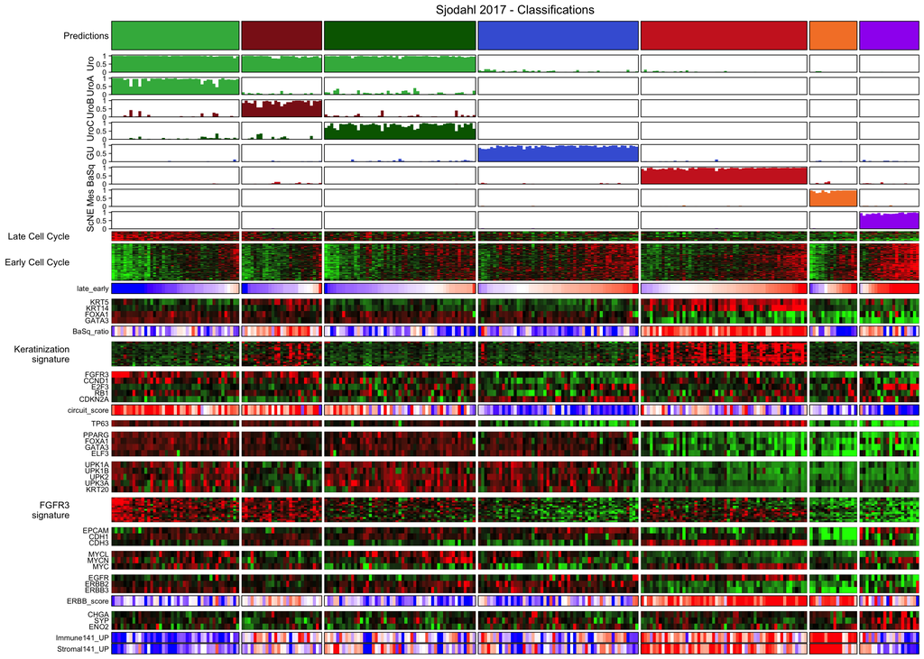

```r
plot_hm_signatures(these_predictions = sjodahl_predicted,
                   this_data = sjodahl_2017,
                   subtype_annotation = "7_class",
                   out_format = "png",
                   out_path = "../man/figures/",
                   gene_id = "hgnc_symbol",
                   title = "Sjodahl 2017 - Classifications")
```

This functions builds a heatmap for the signature scores (4th element in the returned list with the classifier function). This allows for a rapid and comprehenssive overview of how the different signature scores can relate to the different subtypes. In this example, again, we are using the prediction calls from the classifier in the example. The function is called with default paraemters.

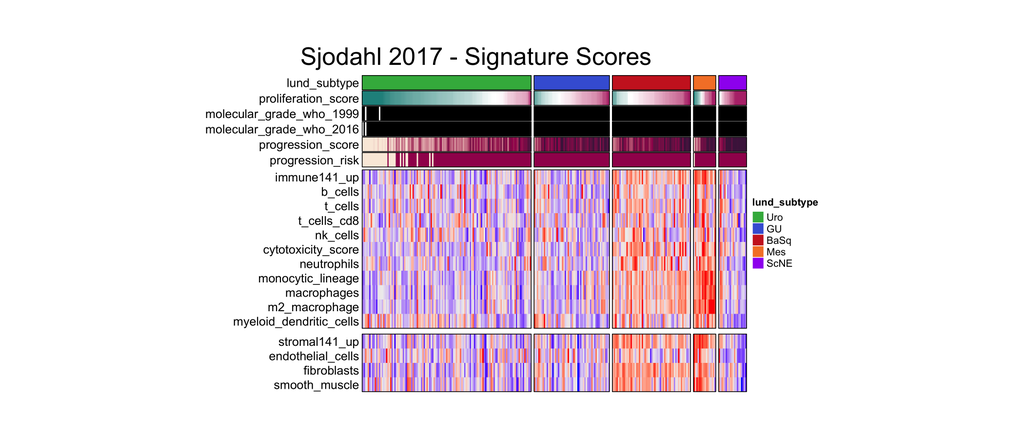

This function can also be run with `return_scores = TRUE` to return the plotting data in a tidy format for the user to either run their own ploting scripts or, aggregating with clinical data, etc. Let’s return this version of the data with the function and see what it looks like.

```
## No output path provided, returning the score data frame in tidy format...
```

Let’s print the column names and type of the returned scores data frame.

```r
str(sjodahl_scores)
```

```
## 'data.frame':    267 obs. of  36 variables:
##  $ proliferation_score               : num  0.731 1.042 0.485 0.66 0.808 ...
##  $ progression_score                 : num  0.768 0.992 0.582 0.78 0.63 ...
##  $ progression_risk                  : Factor w/ 2 levels "HR","LR": 1 1 1 1 1 1 2 1 1 1 ...
##  $ molecular_grade_who_2016_score    : num  0.774 0.746 0.658 0.812 0.781 ...
##  $ molecular_grade_who_2016          : Factor w/ 2 levels "HG","LG": 1 1 1 1 1 1 1 1 1 1 ...
##  $ molecular_grade_who_1999_score    : num  0.807 0.856 0.729 0.865 0.732 ...
##  $ molecular_grade_who_1999          : Factor w/ 2 levels "G1_2","G3": 2 2 2 2 2 2 2 2 2 2 ...
##  $ stromal141_up                     : num  1.88 1.93 1.92 1.88 1.87 ...
##  $ immune141_up                      : num  1.91 2 2.01 1.91 1.94 ...
##  $ b_cells                           : num  1.77 1.79 1.91 1.78 1.77 ...
##  $ b_cells_proportion                : num  0.0737 0.0718 0.0766 0.0735 0.0728 ...
##  $ t_cells                           : num  1.82 1.9 1.97 1.84 1.85 ...
##  $ t_cells_proportion                : num  0.0758 0.0759 0.0787 0.0757 0.0764 ...
##  $ t_cells_cd8                       : num  1.54 1.55 1.7 1.61 1.62 ...
```

[output cut: 22 more lines]

The function can also return the data from in xlsx format. To do so, run the function with `return_xlsx = TRUE`.

### Plot Ranked Score

This function returns a point plot with ranked scores for a set variable. It takes a predictions data set together with a score variable, subtype class and returns a point plot (grob) with ranked scores along the x axis and scores along the y axis. The returned plot will also color fill the points based on subtype classification. In this example, we are plotting proliferation score for all subtypes in the 7 class group.

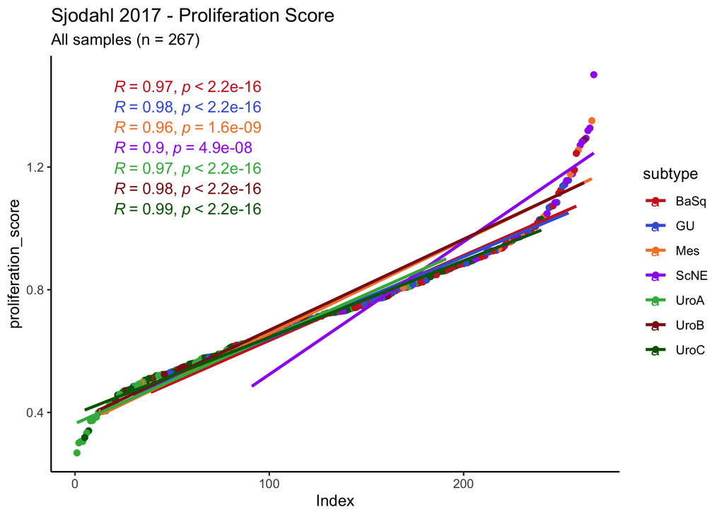